# Interaction: Approach x Inconsistent Level of Abstraction

Julian Frattini

2025-08-30

This notebook contains the analysis of the potential interaction effect between *TLR approach* (`approach`) and *Inconsistent Levels of Abstraction* (`inconsistentloa`) on the outcome (here: `f2`). The analysis provides insight into the hypothesis that some approaches perform differently well for higher levels of design information.

## Data Loading

First, load the data for the observational analysis. The data set is procured by the data-preparation.Rmd notebook. This notebook assembles and casts the data appropriately and stores the results in the `rq4tlr-data.csv` file.

```r
df <- read.csv('./../data/rq4tlr-data.csv')
```

Scale all numeric variables to make their coefficient distributions easier to sample from.

```r
df <- df %>%
  mutate(across(
    c("size", "outlinks", "maxinlinks", "maxsteplength", "sencomplexity"),
    \(x) scale(x, center = TRUE))) %>%
  mutate(
    Approach = factor(Approach, levels=c("FTLR", "LiSSA", "IR", "VSM", "LSI"), ordered = FALSE),
    Category = factor(Category, levels=c("Embedding", "LLM", "Traditional"), ordered = FALSE),
  )

str(df)
```

```
## 'data.frame':    945 obs. of  41 variables:
##  $ Dataset         : chr  "etour" "etour" "etour" "etour" ...
##  $ File            : chr  "UC1" "UC1" "UC1" "UC1" ...
##  $ duplicate       : logi  FALSE FALSE FALSE FALSE FALSE FALSE ...
##  $ nameproblem     : logi  FALSE FALSE FALSE FALSE FALSE FALSE ...
##  $ scope           : logi  FALSE FALSE FALSE FALSE FALSE FALSE ...
##  $ textorder       : logi  FALSE FALSE FALSE FALSE FALSE FALSE ...
##  $ iounquantified  : logi  FALSE FALSE FALSE FALSE FALSE FALSE ...
##  $ actoractor      : logi  FALSE FALSE FALSE FALSE FALSE FALSE ...
##  $ justification   : logi  FALSE FALSE FALSE FALSE FALSE FALSE ...
##  $ coordambiguity  : num  0 0 0 0 0 0 0 0 0 0 ...
##  $ uidesign        : num  0 0 0 0 0 0 0 0 0 0 ...
##  $ alternative     : num  0 0 0 0 0 0 0 0 0 0 ...
##  $ inconsistentloa : num  0 0 0 0 0 0 0 0 0 0 ...
##  $ clarification   : num  0 0 0 0 0 0 0 0 0 0 ...
```

[output cut: 37 more lines]

The output shows by what factors the numeric variables were centered and scaled.

## Analysis

The analysis of the data employs a regression model in a Bayesian framework. The utilized formula only assumes an intercept (i.e., a baseline), an offset per dataset, and the interaction effect between `approach` and the current variable of interest.

```r
f <- F2 ~ 0 + Intercept + Dataset + Approach*inconsistentloa
get_prior(f, data=df, family=zero_one_inflated_beta)
```

```
##              prior class                          coef group resp dpar nlpar lb
##             (flat)     b
##             (flat)     b                    ApproachIR
##             (flat)     b    ApproachIR:inconsistentloa
##             (flat)     b                 ApproachLiSSA
##             (flat)     b ApproachLiSSA:inconsistentloa
##             (flat)     b                   ApproachLSI
##             (flat)     b   ApproachLSI:inconsistentloa
##             (flat)     b                   ApproachVSM
##             (flat)     b   ApproachVSM:inconsistentloa
##             (flat)     b                 Datasetitrust
##             (flat)     b               inconsistentloa
##             (flat)     b                     Intercept
##         beta(1, 1)   coi                                                      0
##  gamma(0.01, 0.01)   phi                                                      0
##         beta(1, 1)   zoi                                                      0
##  ub tag       source
##              default
##         (vectorized)
##         (vectorized)
##         (vectorized)
##         (vectorized)
##         (vectorized)
##         (vectorized)
##         (vectorized)
##         (vectorized)
##         (vectorized)
##         (vectorized)
##         (vectorized)
##   1          default
##              default
##   1          default
```

Given this formula, select uninformative distributions for each of the coefficient distributions.

```r
p1 <- c(
  prior(normal(0, 1), class = b, coef = "Intercept"),
  prior(normal(0, 0.5), class = b),
  prior(gamma(4, 1), class = phi),
  prior(beta(7, 2), class = coi),
  prior(beta(5, 2), class = zoi)
)
```

To confirm the eligibility of the prior distributions, perform a prior predictive check.

```r
m.prior <-
  brm(data = df, family = zero_one_inflated_beta, f, prior = p1,
    iter = 4000, warmup = 1000, chains = 4, cores = 4,
    seed = 4, sample_prior="only",
    file = "../fits/int.f2.approach.inconsistentloa.prior"
  )
```

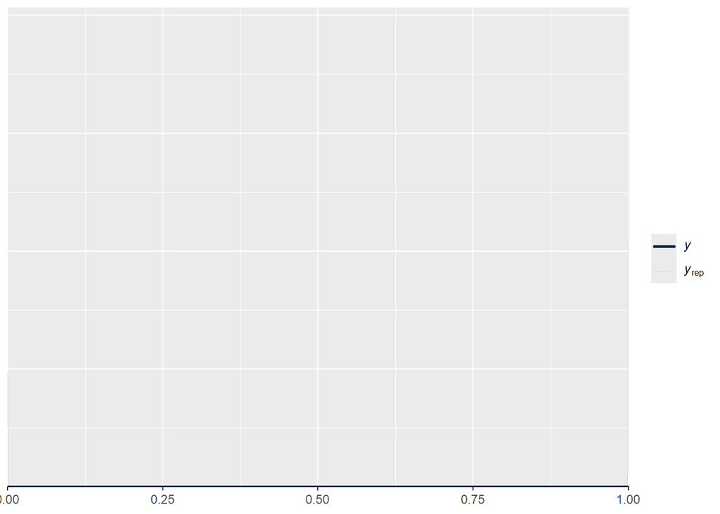

```r
brms::pp_check(m.prior, ndraws=100)
```

Due to the number of interaction effects and the relatively wide priors, the estimation ($y_{rep}$) clusters around the extremes of the spectrum. This is, however, expected and will be overwhelmed by the number of data points.

Given the eligibility of the priors, train the full model by updating the coefficient distributions in light of the observed data.

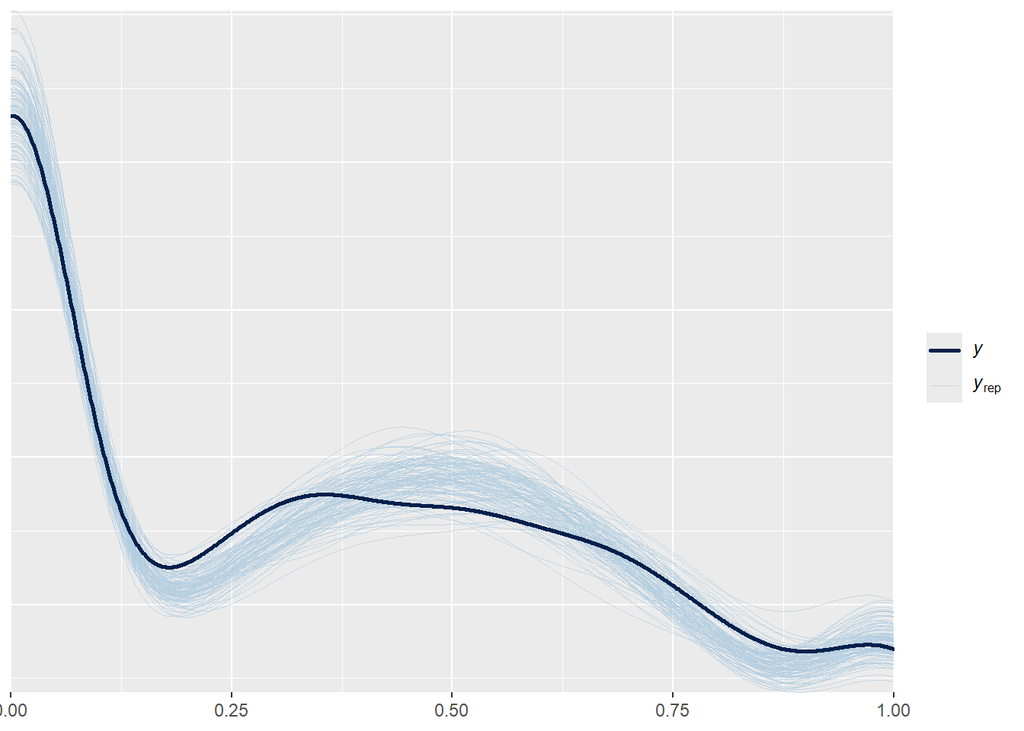

```r
m <-
  brm(data = df, family = zero_one_inflated_beta, f, prior = p1,
    iter = 4000, warmup = 1000, chains = 4, cores = 4, seed = 4,
    file = "../fits/int.f2.approach.inconsistentloa"
  )

brms::pp_check(m, ndraws=100)
```

The posterior predictive check confirms that the model trained properly.

### Evaluation

To evaluate the trained model and draw conclusions about the hypothesized conditional effect, we first look at the updated path coefficients in the model summary. These coefficients are in relation to one selected baseline approach (here: `FTLR`) and represent the average slope difference.

```r
summary(m)
```

```
##  Family: zero_one_inflated_beta
##   Links: mu = logit
## Formula: F2 ~ 0 + Intercept + Dataset + Approach * inconsistentloa
##    Data: df (Number of observations: 945)
##   Draws: 4 chains, each with iter = 4000; warmup = 1000; thin = 1;
##          total post-warmup draws = 12000
##
## Regression Coefficients:
##                               Estimate Est.Error l-95% CI u-95% CI Rhat
## Intercept                         0.28      0.08     0.12     0.44 1.00
## Datasetitrust                    -0.40      0.07    -0.53    -0.27 1.00
## ApproachLiSSA                     0.16      0.10    -0.03     0.35 1.00
## ApproachIR                       -0.51      0.10    -0.70    -0.32 1.00
## ApproachVSM                      -0.16      0.11    -0.38     0.06 1.00
## ApproachLSI                       0.08      0.11    -0.14     0.29 1.00
## inconsistentloa                   0.40      0.25    -0.08     0.87 1.00
## ApproachLiSSA:inconsistentloa    -0.24      0.37    -0.95     0.49 1.00
## ApproachIR:inconsistentloa       -0.27      0.34    -0.93     0.40 1.00
## ApproachVSM:inconsistentloa       0.35      0.45    -0.54     1.24 1.00
## ApproachLSI:inconsistentloa       0.07      0.41    -0.72     0.86 1.00
##                               Bulk_ESS Tail_ESS
## Intercept                         7735     7457
## Datasetitrust                    15874     7931
## ApproachLiSSA                     9096     8450
## ApproachIR                        9262     9545
## ApproachVSM                      10201     9835
## ApproachLSI                       9934     9737
## inconsistentloa                  13974     9154
## ApproachLiSSA:inconsistentloa    15128     9692
## ApproachIR:inconsistentloa       14117     8850
## ApproachVSM:inconsistentloa      17157     8736
## ApproachLSI:inconsistentloa      18371     9224
##
## Further Distributional Parameters:
##     Estimate Est.Error l-95% CI u-95% CI Rhat Bulk_ESS Tail_ESS
## phi     6.30      0.36     5.62     7.03 1.00    17969     8517
## zoi     0.45      0.02     0.42     0.48 1.00    18244     8129
## coi     0.14      0.02     0.11     0.17 1.00    17059     8954
##
## Draws were sampled using sampling(NUTS). For each parameter, Bulk_ESS
## and Tail_ESS are effective sample size measures, and Rhat is the potential
## scale reduction factor on split chains (at convergence, Rhat = 1).
```

More contextualized insights can be derived by plotting the conditional effect.

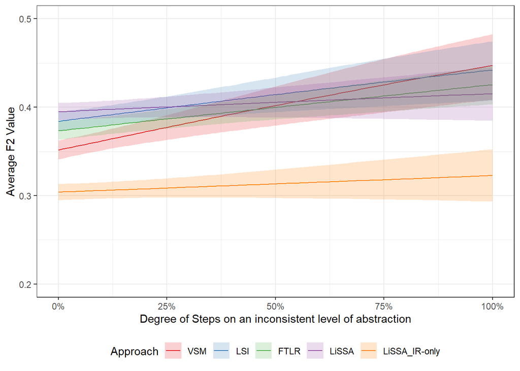

```r
c.eff <- conditional_effects(m, effects="inconsistentloa:Approach",
                    prob = 0.5, method="posterior_epred")

approaches = c("VSM", "LSI", "FTLR", "LiSSA", "LiSSA_IR-only")

c.eff$`inconsistentloa:Approach` %>%
  mutate(Approach = as.character(Approach)) %>%
  mutate(Approach = ifelse(Approach == "IR", "LiSSA_IR-only", Approach)) %>%
  mutate(Approach = factor(Approach, levels = approaches, ordered = TRUE)) %>%
  ggplot(aes(x = inconsistentloa)) +
    geom_line(aes(y = estimate__, color = Approach)) +
    geom_ribbon(aes(ymin = lower__, ymax = upper__, fill = Approach), alpha = 0.2) +
    scale_color_manual(values = brewer.pal(n = 5, name = "Set1"), limits = approaches) +
    scale_fill_manual(values = brewer.pal(n = 5, name = "Set1"), limits = approaches) +
    scale_x_continuous(labels = scales::percent) +
    labs(x = "Degree of Steps on an inconsistent level of abstraction", y = "Average F2 Value") +
    ylim(0.2, 0.5) +
    theme_bw() +
    theme(legend.position = "bottom")
```

```r
ggsave(
  file = file.path(path.figures, "obs-approach-inconsistentloa.pdf"), device = "pdf",
  width = 5.3, height = 3.5)
```

These results invite the following interpretation:

- All approaches respond quite similar.
- VSM improves most, maybe because the named implementation details more effect the keyword-focused approaches and VSM is the only approach that is fully dependent on the same words occurring in the different artifacts.

For joint figures, we extract the data that produces the marginal plot into a file

```r
conditional_effects(m,
                    effects="inconsistentloa:Approach",
                    method="posterior_epred")$`inconsistentloa:Approach` %>%
  select(c("inconsistentloa", "Approach", "estimate__", "lower__", "upper__")) %>%
  rename(qf = "inconsistentloa") %>%
  write_csv(file = "../data/estimates/conditional-inconsistentloa.csv")
```